```python
# https://www.kaggle.com/jackywang529/michelin-restaurants
# use this website u shithead
```

# Michelin star rating analysis

## By: Justin Kallungal

##### The Michelin Guide is a handbook that's purpose is to inform the common person of restaurants that are worth visiting. Nowadays, the Michelin star is a coveted feat that many restaurants aim to achieve, but is there a bias in how Michelin awards these stars? Are there genres of food that they show preference to over others? How about countries?

##### This tutorial aims to explore the trends in the food rating industry by taking a look at one of the most popular rating guides - The Michelin Guide. Throughout the tutorial, we will pose and answer questions in order to uncover meaning behind the *data* in the guide. The following datasets encompass the years 2018 and 2019.

##### *Currently, the data only contains restaurant info in the following regions:*

##### Austria, California, Chicago, Croatia, Czech Republic, Denmark, Finland, Greece, Hong Kong, Hungary, Iceland, Macau, Norway, New York City, Poland, Ireland, Rio de Janeiro, Sao Paulo, South Korea, Singapore, Sweden, Taipei, Thailand, Washington DC, and United Kingdom

##### *Explicitly not including these regions: Belgium, France, Germany, Italy, Japan, Luxembourg, Netherlands, Portugal, China, Spain, and Switzerland*

### Step One: Reading in the Three CSV's

```python
import pandas as pd
import folium
import numpy as np
import matplotlib.pyplot as plt
from sklearn.linear_model import LinearRegression
import seaborn
import statsmodels.api as sm, statsmodels.formula.api as smf


one = pd.read_csv('one-star-michelin-restaurants.csv')
two = pd.read_csv('two-stars-michelin-restaurants.csv')
three = pd.read_csv('three-stars-michelin-restaurants.csv')
one = one.dropna()
two = two.dropna()
three = three.dropna()


two
```

|  | name | year | latitude | longitude | city | region | zipCode | cuisine | price | url |
| --- | --- | --- | --- | --- | --- | --- | --- | --- | --- | --- |
| 0 | SENNS.Restaurant | 2019 | 47.836360 | 13.063890 | Salzburg | Austria | 5020 | Creative | $$$$$ | https://guide.michelin.com/at/en/salzburg-regi... |
| 1 | Ikarus | 2019 | 47.795360 | 13.006950 | Salzburg | Austria | 5020 | Creative | $$$$$ | https://guide.michelin.com/at/en/salzburg-regi... |
| 2 | Mraz & Sohn | 2019 | 48.231290 | 16.376370 | Wien | Austria | 1200 | Creative | $$$$$ | https://guide.michelin.com/at/en/vienna/wien/r... |
| 3 | Konstantin Filippou | 2019 | 48.210560 | 16.379960 | Wien | Austria | 1010 | Modern cuisine | $$$$$ | https://guide.michelin.com/at/en/vienna/wien/r... |
| 4 | Silvio Nickol Gourmet Restaurant | 2019 | 48.205580 | 16.376930 | Wien | Austria | 1010 | Modern cuisine | $$$$$ | https://guide.michelin.com/at/en/vienna/wien/r... |
| 5 | Steirereck im Stadtpark | 2019 | 48.202290 | 16.380500 | Wien | Austria | 1030 | Creative | $$$$$ | https://guide.michelin.com/at/en/vienna/wien/r... |
| 6 | Baumé | 2019 | 37.428500 | -122.142720 | South San Francisco | California | 94306 | Contemporary | $$$$ | https://guide.michelin.com/us/en/california/so... |
| 7 | Commis | 2019 | 37.824760 | -122.255050 | San Francisco | California | 94601 | Contemporary | $$$$ | https://guide.michelin.com/us/en/california/sa... |
| 8 | Californios | 2019 | 37.755550 | -122.417145 | San Francisco | California | 94110 | Mexican | $$$$ | https://guide.michelin.com/us/en/california/sa... |
| 9 | Lazy Bear | 2019 | 37.760204 | -122.419690 | San Francisco | California | 94110 | Contemporary | $$$$ | https://guide.michelin.com/us/en/california/sa... |
| 10 | Saison | 2019 | 37.763270 | -122.415430 | San Francisco | California | 94107 | Californian | $$$$ | https://guide.michelin.com/us/en/california/sa... |
| 11 | Campton Place | 2019 | 37.789230 | -122.406650 | San Francisco | California | 94108 | Indian | $$$$ | https://guide.michelin.com/us/en/california/sa... |
| 12 | Coi | 2019 | 37.798120 | -122.403310 | San Francisco | California | 94133 | Contemporary | $$$$ | https://guide.michelin.com/us/en/california/sa... |
| 13 | Acquerello | 2019 | 37.791670 | -122.421310 | San Francisco | California | 94109 | Italian | $$$$ | https://guide.michelin.com/us/en/california/sa... |
| 14 | Urasawa | 2019 | 34.067352 | -118.400670 | Los Angeles | California | 90210 | Japanese | $$$$ | https://guide.michelin.com/us/en/california/us... |
| 16 | Somni | 2019 | 34.070095 | -118.376490 | Los Angeles | California | 90048 | Contemporary | $$$$ | https://guide.michelin.com/us/en/california/us... |
| 17 | Providence | 2019 | 34.083523 | -118.330190 | Los Angeles | California | 90028 | Seafood | $$$$ | https://guide.michelin.com/us/en/california/us... |
| 18 | n/naka | 2019 | 34.025260 | -118.412060 | Los Angeles | California | 90034 | Contemporary | $$$$ | https://guide.michelin.com/us/en/california/us... |
| 19 | Vespertine | 2019 | 34.024204 | -118.381660 | Los Angeles | California | 90232 | Contemporary | $$$$ | https://guide.michelin.com/us/en/california/us... |
| 20 | Smyth | 2019 | 41.885000 | -87.660736 | Chicago | Chicago | 60607 | Contemporary | $$$$ | https://guide.michelin.com/us/en/illinois/chic... |
| 21 | Oriole | 2019 | 41.886196 | -87.645130 | Chicago | Chicago | 60661 | Contemporary | $$$$ | https://guide.michelin.com/us/en/illinois/chic... |
| 22 | Acadia | 2019 | 41.859040 | -87.625620 | Chicago | Chicago | 60616 | Contemporary | $$$$ | https://guide.michelin.com/us/en/illinois/chic... |
| 23 | KOKS | 2019 | 62.136670 | -7.022025 | Leynar | Denmark | 335 | Creative | $$$$ | https://guide.michelin.com/dk/en/faroe-islands... |
| 24 | Henne Kirkeby Kro | 2019 | 55.726820 | 8.242021 | Henne | Denmark | 6854 | Classic cuisine | $$$ | https://guide.michelin.com/dk/en/southern-denm... |
| 25 | a‚o‚c | 2019 | 55.683050 | 12.589210 | København | Denmark | 1302 K | Modern cuisine | $$$$ | https://guide.michelin.com/dk/en/capital-regio... |
| 26 | noma | 2019 | 55.683320 | 12.610060 | København | Denmark | 1432 K | Creative | $$$$ | https://guide.michelin.com/dk/en/capital-regio... |
| 27 | Kadeau Copenhagen | 2019 | 55.672190 | 12.588480 | København | Denmark | 1408 K | Modern cuisine | $$$$ | https://guide.michelin.com/dk/en/capital-regio... |
| 28 | Spondi | 2019 | 37.965250 | 23.742971 | Athína | Greece | 116 36 | French | $$$$$ | https://guide.michelin.com/gr/en/attica/athina... |
| 41 | Onyx | 2019 | 47.497120 | 19.050670 | Budapest | Hungary | 1051 | Modern cuisine | $$$$$ | https://guide.michelin.com/hu/en/central-hunga... |
| 48 | Jungsik | 2019 | 40.718685 | -74.009110 | New York | New York City | 10013 | Korean | $$$$ | https://guide.michelin.com/us/en/new-york-stat... |
| 49 | Atera | 2019 | 40.716797 | -74.005650 | New York | New York City | 10013 | Contemporary | $$$$ | https://guide.michelin.com/us/en/new-york-stat... |
| 50 | Jean-Georges | 2019 | 40.769070 | -73.981550 | New York | New York City | 10023 | Contemporary | $$$$ | https://guide.michelin.com/us/en/new-york-stat... |
| 51 | Marea | 2019 | 40.767490 | -73.981140 | New York | New York City | 10019 | Seafood | $$$$ | https://guide.michelin.com/us/en/new-york-stat... |
| 52 | Gabriel Kreuther | 2019 | 40.753970 | -73.982025 | New York | New York City | 10036 | Contemporary | $$$$ | https://guide.michelin.com/us/en/new-york-stat... |
| 53 | Ichimura at Uchū | 2019 | 40.721832 | -73.990120 | New York | New York City | 10002 | Japanese | $$$$ | https://guide.michelin.com/us/en/new-york-stat... |
| 54 | Sushi Ginza Onodera | 2019 | 40.752396 | -73.981575 | New York | New York City | 10017 | Japanese | $$$$ | https://guide.michelin.com/us/en/new-york-stat... |
| 55 | Ko | 2019 | 40.729090 | -73.984480 | New York | New York City | 10003 | Contemporary | $$$$ | https://guide.michelin.com/us/en/new-york-stat... |
| 56 | The Modern | 2019 | 40.761060 | -73.976280 | New York | New York City | 10019 | Contemporary | $$$$ | https://guide.michelin.com/us/en/new-york-stat... |
| 57 | Aquavit | 2019 | 40.760780 | -73.972140 | New York | New York City | 10022 | Scandinavian | $$$$ | https://guide.michelin.com/us/en/new-york-stat... |
| 58 | Daniel | 2019 | 40.766600 | -73.967450 | New York | New York City | 10065 | French | $$$$ | https://guide.michelin.com/us/en/new-york-stat... |
| 59 | Aska | 2019 | 40.712220 | -73.966420 | New York | New York City | 11249 | Scandinavian | $$$$ | https://guide.michelin.com/us/en/new-york-stat... |
| 60 | Blanca | 2019 | 40.704920 | -73.933540 | New York | New York City | 11206 | Contemporary | $$$$ | https://guide.michelin.com/us/en/new-york-stat... |
| 62 | Oro | 2019 | -22.986010 | -43.224710 | Rio de Janeiro - 22441 | Rio de Janeiro | 015 | creative | $$$$$ | https://guide.michelin.com/br/en/rio-de-janeir... |
| 63 | Tuju | 2019 | -23.556530 | -46.690830 | São Paulo - 05416 | Sao Paulo | 001 | creative | $$$$$ | https://guide.michelin.com/br/en/sao-paulo-reg... |
| 64 | D.O.M. | 2019 | -23.566180 | -46.667420 | São Paulo - 01411 | Sao Paulo | 011 | creative | $$$$$ | https://guide.michelin.com/br/en/sao-paulo-reg... |
| 75 | Fäviken Magasinet | 2019 | 63.436260 | 13.293370 | Järpen | Sweden | 837 94 | Creative | $$$$ | https://guide.michelin.com/se/en/jamtland/jarp... |
| 76 | Gastrologik | 2019 | 59.333650 | 18.080700 | Stockholm | Sweden | 114 51 | Creative | $$$$ | https://guide.michelin.com/se/en/stockholm-reg... |
| 77 | Oaxen Krog | 2019 | 59.322342 | 18.101831 | Stockholm | Sweden | 11521 | Creative | $$$$ | https://guide.michelin.com/se/en/stockholm-reg... |
| 78 | Vollmers | 2019 | 55.604427 | 12.995848 | Malmö | Sweden | 21133 | Creative | $$$$ | https://guide.michelin.com/se/en/skane/malmo/r... |
| 79 | Daniel Berlin | 2019 | 55.612460 | 13.992650 | Skåne-Tranås | Sweden | 273 92 | Creative | $$$$ | https://guide.michelin.com/se/en/skane/skane-t... |
| 80 | RAW | 2019 | 25.082666 | 121.559525 | Taipei | Taipei | 110 | Innovative | $$$ | https://guide.michelin.com/tw/en/taipei-region... |
| 81 | Shoun RyuGin | 2019 | 25.082580 | 121.559500 | Taipei | Taipei | 110 | Japanese contemporary | $$$$ | https://guide.michelin.com/tw/en/taipei-region... |
| 82 | Taïrroir | 2019 | 25.082718 | 121.559296 | Taipei | Taipei | 110 | Innovative | $$$ | https://guide.michelin.com/tw/en/taipei-region... |
| 83 | Sushi Amamoto | 2019 | 25.037945 | 121.554870 | Taipei | Taipei | 110 | Sushi | $$$$ | https://guide.michelin.com/tw/en/taipei-region... |
| 84 | The Guest House | 2019 | 25.044860 | 121.521980 | Taipei | Taipei | 110 | Sichuan-Huai Yang | $$ | https://guide.michelin.com/tw/en/taipei-region... |
| 89 | minibar | 2019 | 38.896294 | -77.023860 | Washington, D.C. | Washington DC | 20004 | Contemporary | $$$$ | https://guide.michelin.com/us/en/washington/wa... |
| 90 | Pineapple and Pearls | 2019 | 38.880707 | -76.995140 | Washington, D.C. | Washington DC | 20003 | Contemporary | $$$$ | https://guide.michelin.com/us/en/washington/wa... |

### Step Two: Data Representation and Exploratory Data Analysis

##### *Getting an idea of what we can find from the data*

```python
#
# three['region'].value_counts()

# two['cuisine'].value_counts()

m = folium.Map()

# One star
for _, row in one.iterrows():
    lat = float(row['latitude'])
    lon = float(row['longitude'])
    folium.CircleMarker(
    [lat, lon],radius=3, popup=row['name'], tooltip=row['cuisine'], color='red').add_to(m)

# Two star
for _, row in two.iterrows():
    lat = float(row['latitude'])
    lon = float(row['longitude'])
    folium.CircleMarker(
    [lat, lon],radius=3, popup=row['name'], tooltip=row['cuisine'], color='blue').add_to(m)


for _, row in three.iterrows():
    lat = float(row['latitude'])
    lon = float(row['longitude'])
    folium.CircleMarker(
    [lat, lon],radius=3, popup=row['name'], tooltip=row['cuisine'], color='pink').add_to(m)

m
```

Make this Notebook Trusted to load map: File -> Trust Notebook

[interactive chart not shown]

> So what are some quick abstractions from this map? For starters, it seems as though Western Europe hold the bulk of Michelin rated restaurants; specifically in the United Kingdom. The interesting thing to note here is that even though France is the origin of the Michelin Guide, these 3 data-sets do not include any of the datapoints within the country. Although this data excludes a few major countries (Belgium, France, Germany, Italy, Japan, Luxembourg, Netherlands, Portugal, China, Spain, and Switzerland), we are going to focus on the countries that **do** have representation to understand the sampling.

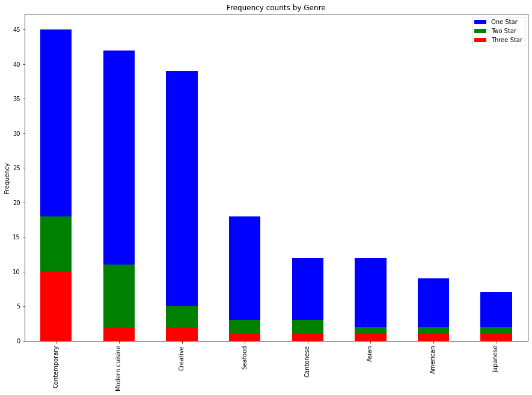

```python
# Getting an idea for the value counts of all three


plt.figure(figsize=(15, 10))
plt.yticks(np.arange(0, 110, 5))
one['cuisine'].value_counts().plot.bar(color = 'blue')
two['cuisine'].value_counts().plot.bar(color = 'green')
three['cuisine'].value_counts().plot.bar(color = 'red')

plt.ylabel("Frequency")
plt.title("Frequency counts by Genre")
plt.legend(['One Star','Two Star','Three Star'])
```

> This graph makes clear the idea that michelin tends to - across all 3 star ratings - prefer the same genre of restaurants. Seeing that California is the most heavily populated region, can we say that these top n genres hold true within the California?

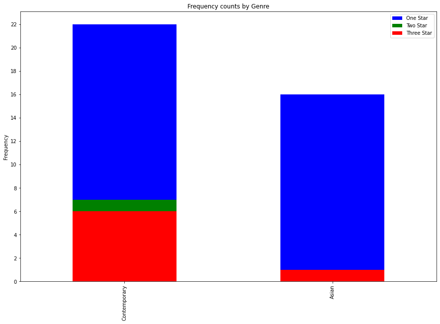

```python
first = []
second = []
third = []
for _, i in one.iterrows():
    if i['region'] == 'California':
        first.append(i['cuisine'])

for _, i in two.iterrows():
    if i['region'] == 'California':
        second.append(i['cuisine'])

for _, i in three.iterrows():
    if i['region'] == 'California':
        third.append(i['cuisine'])


# first
fig = plt.figure()
plt.figure(figsize=(15, 10))
plt.yticks(np.arange(0, 50, 2))

first = pd.DataFrame({'one': first})
first['one'].value_counts().plot.bar(color = 'blue')

second = pd.DataFrame({'two': second})
second['two'].value_counts().plot.bar(color = 'green')

third = pd.DataFrame({'three': third})
third['three'].value_counts().plot.bar(color = 'red')



plt.ylabel("Frequency")
plt.title("Frequency counts by Genre")
plt.legend(['One Star','Two Star','Three Star'])
plt.show()
```

### Is the Michelin Guide truly accessible to the average consumer?

##### The main reason this guide exists is to recommend quality restaurants to the average consumer. Michelin argues that they filter out the ultra-expensive/exclusive restaurants as they are not accessible, but is that true? What dictates accessibility?

##### There are 5 categories of price, all represented by increasing amounts of '$'

```python
print(one['price'].value_counts(), end = "\n\n")
print(two['price'].value_counts(), end = "\n\n")
print(three['price'].value_counts(), end = "\n\n")
```

```
$$$$     102
$$$       85
$$$$$     38
$$        33
$          1
Name: price, dtype: int64

$$$$     42
$$$$$    11
$$$       3
$$        1
Name: price, dtype: int64

$$$$     17
$$$$$     1
$$        1
Name: price, dtype: int64
```

### Hypothesis testing

##### Can we draw a correlation between the length of a restaurant's name and its price?

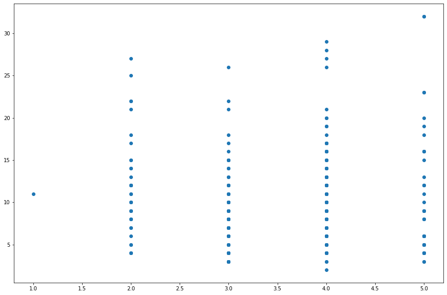

```python
nameLen = []
rate = []
#for _, row in one.iterrows():
#     print(row.name)
plt.figure(figsize=(15, 10))
for _, row in one.iterrows():
    row['price'] = len(row['price'])
    row['name'] = len(row['name'])
    rate.append(row['price'])
    nameLen.append(row['name'])

for _, row in two.iterrows():
    row['price'] = len(row['price'])
    row['name'] = len(row['name'])
    rate.append(row['price'])
    nameLen.append(row['name'])

for _, row in three.iterrows():
    row['price'] = len(row['price'])
    row['name'] = len(row['name'])
    rate.append(row['price'])
    nameLen.append(row['name'])



plt.scatter(rate, nameLen)
# plt.violinplot(nameLen, rate,showmeans=True)
# rate
# nameLen
```

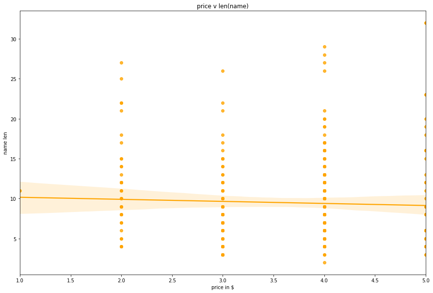

```python
x = rate
y = nameLen
plt.figure(figsize=(15, 10))
plt.title("price v len(name)")
plt.xlabel('price in $')
plt.ylabel('name len')
ax = seaborn.regplot(x=rate, y=nameLen, color = 'orange')
```

> The linear regression here negatively correlates with the idea that length of restaurant name impacts pricing!

### Results?

> From this analysis, we can see that there are many metrics that this data-set takes in. Michelin is careful in their selection of restaurants for their guide. This analysis shows that there is a bias towards contemporary genre'd restaurants (within the given dataset). We attempted to look at the general feel of the price v len(name) metric, but found that it was not correlated!